# Formatieve opdracht script rna sequencing

Thijmen van Brenk, Pedro de Bos

2022-04-04

# onderdeel les 1

in deze Rmarkdown wordt er gekeken of er een verschil is in genexpressie tussen induced pluripotent stem cells(IPSC) en fibroblasten (hieruit zijn IPSC gemaakt) om dit te onderzoeken is er een RNA-sequencing experiment uitgevoerd met 2 fibroblast cell lines. uit deze 2 lijnen zijn ook 2 IPSC lijnen gemaakt. dit experiment is in duplo uitgevoerd.

**Downloaden fastq bestanden mbv fastq-dump in bash**

```bash
for id in $(cat /home/1760065/daur2/formatieve_opdracht_rna-seq/bestanden/SSR_IPSC.txt)
do
  echo fastq-dump --split-3 --outdir 'bestanden/fastq' --gzip $id
  echo $id is gedownload
done
```

```
## fastq-dump --split-3 --outdir bestanden/fastq --gzip SRR7866687
## SRR7866687 is gedownload
## fastq-dump --split-3 --outdir bestanden/fastq --gzip SRR7866688
## SRR7866688 is gedownload
## fastq-dump --split-3 --outdir bestanden/fastq --gzip SRR7866689
## SRR7866689 is gedownload
## fastq-dump --split-3 --outdir bestanden/fastq --gzip SRR7866690
## SRR7866690 is gedownload
## fastq-dump --split-3 --outdir bestanden/fastq --gzip SRR7866691
## SRR7866691 is gedownload
## fastq-dump --split-3 --outdir bestanden/fastq --gzip SRR7866692
## SRR7866692 is gedownload
## fastq-dump --split-3 --outdir bestanden/fastq --gzip SRR7866693
## SRR7866693 is gedownload
## fastq-dump --split-3 --outdir bestanden/fastq --gzip SRR7866694
## SRR7866694 is gedownload
```

**Per base sequence quality:** voor alle bestanden zit de gemiddelde kwualiteit boven een score van 28.  
**Per sequence quality scores:** voor alle bestanden zit het overgrote aantal baseparen boven een scorde van 28.  
De FastQ bestanden zijn goed genoeg om gebruikt te worden.

**allignen van het RNA tegenover het humane genoom**

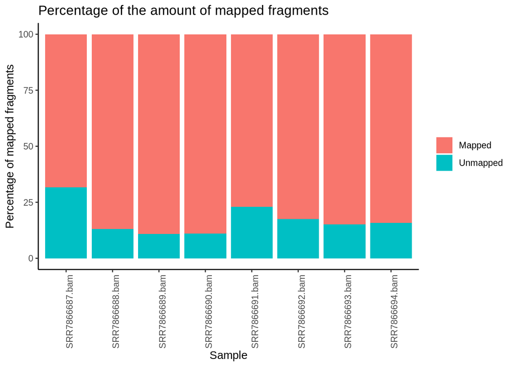

```r
## maak eerst de directories aan voor de bestand locaties zodat deze gebruikt kunnen worden voor het allignen

hg38_index <- "/home/daur2/rnaseq/hg38_index/"
fastq_dir <- "bestanden/fastq/"
samples <- list.files(fastq_dir, pattern = "_[12].fastq.gz") %>%
  str_remove(pattern = "_[12].fastq.gz") %>%
  unique()
bam_dir <- "bestanden/bam/"

## nu kan de allignment uitgevoerd worden

# alignment_statistics <- align(
#  index = hg38_index,
#  readfile1 = paste0(fastq_dir, samples, "_1.fastq.gz"),
#  readfile2 = paste0(fastq_dir, samples, "_2.fastq.gz"),
#  type = "rna", input_format = "gzFASTQ", output_format = "BAM",
#  output_file = paste0(bam_dir, samples, ".bam"),
#  unique = T,
#  nthreads = 10
# )

alignment_statistics <- readRDS("/home/1760065/daur2/formatieve_opdracht_rna-seq/bestanden/bam/alignment_statistics.rds")

## voeg het percentage gemapped en niet gemapped toe aan de tibble
alignment_statistics_tidy <- alignment_statistics %>%
  t() %>%
  as_tibble() %>%
  mutate(bamfiles = colnames(alignment_statistics)) %>%
  mutate(perc_mapped = Mapped_fragments * 100 / Total_fragments) %>%
  mutate(perc_unmapped = 100 - perc_mapped)

## maak van de percentages 1 kolom voor het makkelijk maken van een grafiek
alignment_statistics_summary <- alignment_statistics_tidy %>%
  pivot_longer(cols = c("perc_mapped", "perc_unmapped"),
               names_to = "type_of_percentage", values_to = "percentages")

## maak een grouped bar chart
alignment_statistics_summary %>%
  ggplot(aes(x = bamfiles, y = percentages, fill = type_of_percentage)) +
  geom_col() +
  labs(title = "Percentage of the amount of mapped fragments",
       x = "Sample",
       y = "Percentage of mapped fragments",
       fill = " ") +
  scale_fill_discrete(labels = c("Mapped", "Unmapped")) +
  theme_classic() +
  theme(axis.text.x = element_text(angle = 90))
```

# onderdeel les 2

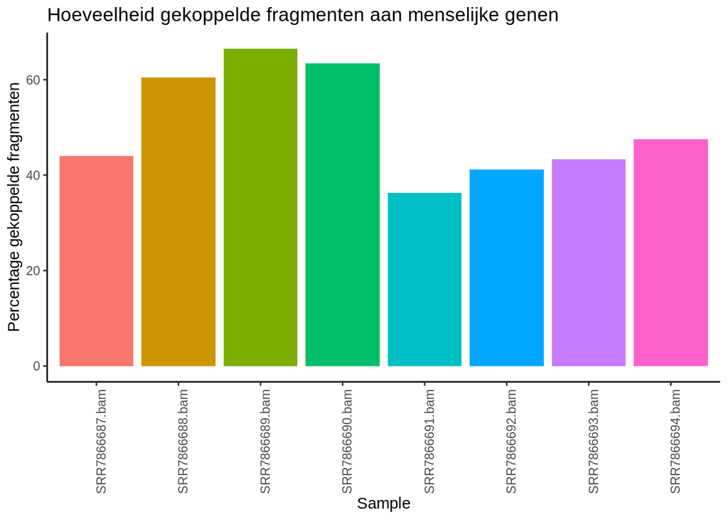

```r
## maak eerst de directories aan om de bestanden te vinden en op te slaan

counts_dir <- "bestanden/counts"
bam_files <- list.files(bam_dir, pattern = ".\\.bam$", full.names = T)

## nu kunnen we een count table maken

# read_counts <- featureCounts(
#
#  files = bam_files,
#  annot.inbuilt = "hg38",
#  useMetaFeatures = TRUE,
#  strandSpecific = 0,
#  isPairedEnd = TRUE,
#  countReadPairs = TRUE,
#  nthreads = 10
# )

## om een staafdiagram te maken maken we eerst een geschikte dataframe
read_counts <- readRDS("/home/1760065/daur2/formatieve_opdracht_rna-seq/bestanden/counts/read_counts.rds")
count_stats <- read_counts$stat

# maak eerst de rows netjes
rownames(count_stats) <- count_stats$Status
count_stats$Status <- NULL

# voeg de extra gegevens toe
count_stats_tidy <- count_stats %>%
  t() %>%
  as_tibble() %>%
  mutate(total = colSums(count_stats)) %>%
  mutate(perc_assigned = Assigned * 100 / total) %>%
  mutate(bamfile = colnames(count_stats))

# maak nu de grafiek

count_stats_tidy %>%
  ggplot(aes(x = bamfile, y = perc_assigned, fill = bamfile)) +
  geom_col() +
  theme_classic() +
  theme(axis.text.x = element_text(angle = 90), legend.position = "hide") +
  labs(title = "Hoeveelheid gekoppelde fragmenten aan menselijke genen",
       x = "Sample",
       y = "Percentage gekoppelde fragmenten")
```

Ongeveer 50% van de fragmenten kunnen gekoppeld worden aan genen in het menselijk genoom.  
De rest komt van andere delen van het genoom.

```r
# maak de count matrix en de metadata
count_matrix <- read_counts$counts

metadata <- read_csv("/home/1760065/daur2/formatieve_opdracht_rna-seq/bestanden/ipsc_sampledata.csv")
metadata <- as.data.frame(metadata)
rownames(metadata) <- paste0(metadata$Run, ".bam")

# controle of matrix en metadata gelijk zijn
colnames(count_matrix) == rownames(metadata)
```

```
## [1] TRUE TRUE TRUE TRUE TRUE TRUE TRUE TRUE
```

```r
# het verschil tussen de cell_types moet onderzocht worden dus gebruiken we deze kolom
# deze moet eerst tot factor gemaakt worden
metadata <- metadata %>% mutate(Cell_type = str_replace(Cell_type, "Skin derived fibroblast", "Skin_derived_fibroblast"))
metadata$Cell_type <- as.factor(metadata$Cell_type)

# nu moet de data zo neer gezet worden zodat de fibroblasten lijn voor de IPSC cells van dezelfde lijn komt te staan
metadata <- metadata[c(1,5,2,6,3,7,4,8), ]


# ook de count_matrix moet aangepast worden op volgorde
count_matrix <- count_matrix[, c(1,5,2,6,3,7,4,8)]

# check nu weer of ze gelijk zijn
colnames(count_matrix) == rownames(metadata)
```

```
## [1] TRUE TRUE TRUE TRUE TRUE TRUE TRUE TRUE
```

```r
# dan kunnen we nu de DESeqDataSet maken

dds <- DESeqDataSetFromMatrix(
  countData = count_matrix,
  colData = metadata,
  design = ~ Cell_type
)

# nu we de DESeq data hebben kunnen we hier een PC analyze op runnen

## eerst normalizeren zodat de verschillen zichtbaarder zijn
dds_normalized <- rlog(dds)

## nu de pca analyze uitvoeren
pca <- dds_normalized %>% assay() %>% t() %>% prcomp()

## nu hebben we de variabelen dus laten we kijken naar de hoeveelheid variatie tussen de variabelen
pca_summary <- summary(pca)$importance
pca_summary
```

```
##                             PC1      PC2      PC3      PC4      PC5      PC6
## Standard deviation     142.2719 40.35777 32.49051 23.05517 20.72753 20.56573
## Proportion of Variance   0.8221  0.06615  0.04287  0.02159  0.01745  0.01718
## Cumulative Proportion    0.8221  0.88826  0.93113  0.95272  0.97017  0.98735
##                             PC7          PC8
## Standard deviation     17.65039 1.517815e-13
## Proportion of Variance  0.01265 0.000000e+00
## Cumulative Proportion   1.00000 1.000000e+00
```

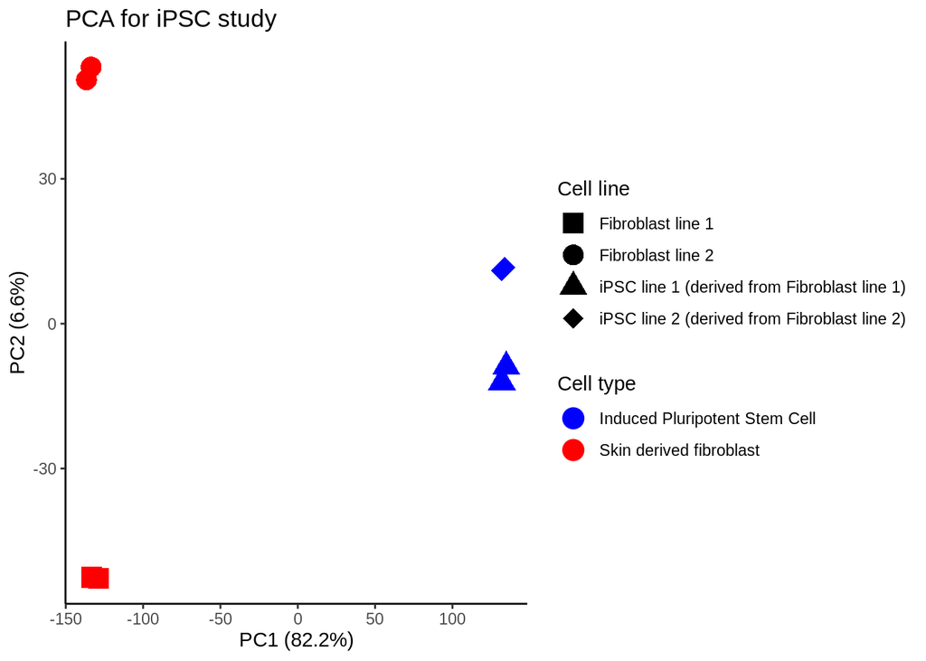

```r
# PC1 en PC2 hebben samen al 90% van de variatie
# hier kunnen we plot van maken

pca_plotting <- cbind(metadata, pca$x)

PC1_var <- round(pca_summary["Proportion of Variance", "PC1"]*100, digits = 1)
PC2_var <- round(pca_summary["Proportion of Variance", "PC2"]*100, digits = 1)

ggplot(pca_plotting) +
  geom_point(aes(x = PC1, y= PC2, color = Cell_type, shape = Cell_line), size = 5) +
  theme_classic() +
  labs(title = "PCA for iPSC study",
       x = paste0("PC1 (", PC1_var, "%)"),
       y = paste0("PC2 (", PC2_var, "%)"),
       color = "Cell type",
       shape = "Cell line") +
  scale_color_manual(labels = c("Induced Pluripotent Stem Cell", "Skin derived fibroblast"), values = c("blue", "red")) +
  scale_shape_manual(labels = c("Fibroblast line 1", "Fibroblast line 2",
                                "iPSC line 1 (derived from Fibroblast line 1)", "iPSC line 2 (derived from Fibroblast line 2)"),
                     values = c(15,16,17,18))
```

uit deze grafiek kan geconcludeerd worden dat **80%** van de variatie zit tussen de iPSC en de fibroblasten

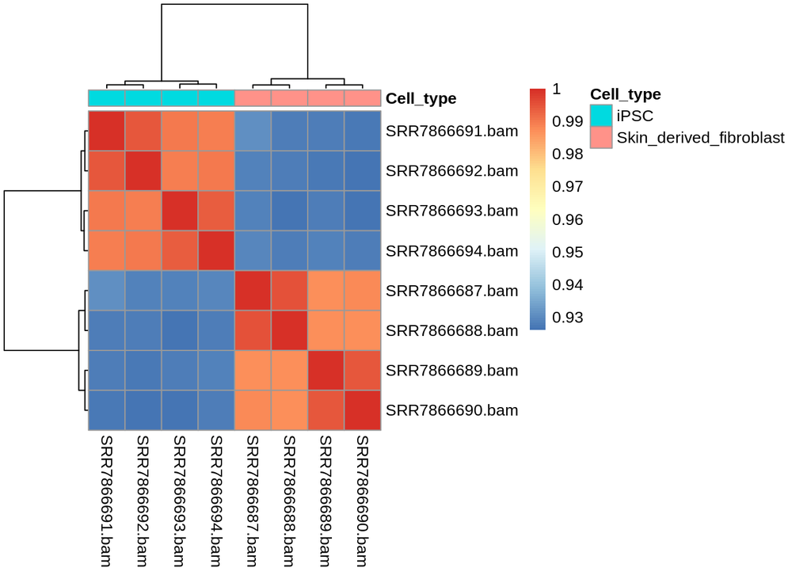

```r
# haal eerst de matrix uit de DESeq data
dds_normalized_matrix <- assay(dds_normalized)

# voer nu de correlatie test uit
iPSC_cor <- cor(dds_normalized_matrix)

# maak nu de heatmap

pheatmap(iPSC_cor, annotation = metadata["Cell_type"])
```

de stamcellen en de fibroblasten liggen ver uit elkaar met variance.